# Ampliseq WECARE only PCA

Alexey Larionov

23 Dec 2021

# 1 Summary

Had to suppress the smoothing log-p-values: see details in the script

PCA for ampliseq-only (b37) wes dataset w/o Danish:

- Shows no irregularities in PCA analysis
- Provides evidence for using top 2 PC-s in regression model
- There was possibly one PCA outlier; however, with such small number of variants it was likely to be spurious; also it was in the 5th PC (at the best), so it was not excluded

# 2 Start section

```r
# Time stamp
Sys.time()
```

```
## [1] "2021-12-23 21:28:59 GMT"
```

```r
# Clenan-up
rm(list=ls())
graphics.off()

# Memory
gc()
```

```
##          used (Mb) gc trigger (Mb) limit (Mb) max used (Mb)
## Ncells 434026 23.2     919382 49.2         NA   641382 34.3
## Vcells 831443  6.4    8388608 64.0      16384  1769100 13.5
```

```r
# Options
options(stringsAsFactors = F,
        warnPartialMatchArgs = T,
        warnPartialMatchAttr = T,
        warnPartialMatchDollar = T)

# Working folders
base_folder="/Users/alexey/Documents/wecare/final_analysis_2021/reanalysis_afterNov2021/ampliseq/s01_ampliseq_wecare_only"
data_folder <- file.path(base_folder,"data","s07_relatedness_and_pca")
scripts_folder <- file.path(base_folder,"scripts","s07_relatedness_and_pca")
setwd(scripts_folder)

# Libraries
library(bigsnpr) # for bed_autoSVD() and bed()
```

```r
library(bigutilsr) # for prob_dist() and tukey_mc_up() for outlier detection
library(hexbin) # for plotting svd loadings
library(ggplot2)
library(dplyr)
NCORES <- 1
#NCORES <- nb_cores() # 2
```

# 3 Read bed-bim-fam file-set

```r
# Location of bed file
bed_file <- file.path(data_folder,"s02_bed_bim_fam","common_biallelic_autosomal_snps_in_HWE.bed")

# Attach PLINK data to R environment
wecare.bed <- bed(bed_file) # bigsnpr::bed

# Explore wecare.bed
wecare.bed
```

```
## A 'bed' object with 389 samples and 470 variants.
```

```r
names(wecare.bed)
```

```
##  [1] ".->bedfile"   "light"        ".self"        ".->.map"      "show"         "extptr"       "nrow"         "bimfile"      ".refClassDef" "bedfile"      "ncol"         "initialize"   "map"          "fam"          ".map"         ".->extptr"    "famfile"      ".fam"         "address"      ".->.fa…
```

```r
#attributes(wecare.bed)
#str(wecare.bed)
#wecare.bed$bedfile
#wecare.bed$address

# Clean-up
rm(bed_file)
```

# 4 Phenotypes

```r
# Phenotypes from plink
wecare_fam.df <- wecare.bed$fam
dim(wecare_fam.df)
```

```
## [1] 389   6
```

```r
head(wecare_fam.df)
```

```
##     family.ID   sample.ID paternal.ID maternal.ID sex affection
## 1 1_S441_L008 1_S441_L008           0           0   2         1
## 2 2_S134_L007 2_S134_L007           0           0   2         2
## 3 3_S360_L008 3_S360_L008           0           0   2         2
## 4  4_S66_L007  4_S66_L007           0           0   2         1
## 5 5_S395_L008 5_S395_L008           0           0   2         2
## 6 6_S172_L007 6_S172_L007           0           0   2         1
```

```r
# Phenotypes from the main dataset file
load(file.path(base_folder,"data","s06_qc_filters","s04_check_samples.RData"))
rm(genotypes.mx,variants.df)

# Update folders
base_folder="/Users/alexey/Documents/wecare/final_analysis_2021/reanalysis_afterNov2021/ampliseq/s01_ampliseq_wecare_only"
data_folder <- file.path(base_folder,"data","s07_relatedness_and_pca")
scripts_folder <- file.path(base_folder,"scripts","s07_relatedness_and_pca")

dim(phenotypes.df)
```

```
## [1] 389  25
```

```r
colnames(phenotypes.df)
```

```
##  [1] "long_ids"         "illumina_id"      "illumina_lane"    "Sample_num"       "cc"               "rstime"           "sub_dx_age"       "hormone_self_mra" "chemo_self_mra"   "treatment"        "Hist_lob_other"   "stage_fd"         "histo1_cat"       "er1_cat"          "pr1_cat"          "grade1…
```

```r
#str(phenotypes.df)
#table(phenotypes.df$filter)
#phenotypes.df[phenotypes.df$filter=="eigenvectors_outlier","wes_id"]
#"Possibly_related_to_P1-D05" -> phenotypes.df[phenotypes.df$wes_id=="P5_C12","filter"]

# Merge fam-file and phenotypes from the main dataset
# (removing samples that are not in fam-file)
wecare_phenotypes.df <- left_join(wecare_fam.df, phenotypes.df,
                                  by=c("sample.ID"="long_ids"))
dim(wecare_phenotypes.df)
```

```
## [1] 389  30
```

```r
colnames(wecare_phenotypes.df)
```

```
##  [1] "family.ID"        "sample.ID"        "paternal.ID"      "maternal.ID"      "sex"              "affection"        "illumina_id"      "illumina_lane"    "Sample_num"       "cc"               "rstime"           "sub_dx_age"       "hormone_self_mra" "chemo_self_mra"   "treatment"        "Hist_l…
```

```r
#sum(wecare_phenotypes.df$sample.ID == "P5_C12")

# Make sure that dplyr::left_joint hasnt changed the order of samples
sum(wecare_phenotypes.df$sample.ID != wecare_fam.df$sample.ID)
```

```
## [1] 0
```

```r
# Add column for outliers
wecare_phenotypes.df <- data.frame(wecare_phenotypes.df,outlier=F)

# Clean-up
rm(phenotypes.df, wecare_fam.df)
```

# 5 Explore variants

Data from bed-bim-fam only: explored; not needed for PCA calculation

```r
# map file
wecare_map.df <- wecare.bed$map
dim(wecare_map.df)
```

```
## [1] 470   6
```

```r
head(wecare_map.df)
```

```
##   chromosome      marker.ID genetic.dist physical.pos allele1 allele2
## 1          1  1_3669172_C_T            0      3669172       T       C
## 2          1  1_3677933_T_C            0      3677933       C       T
## 3          1  1_3684107_T_A            0      3684107       A       T
## 4          1  1_3688030_C_G            0      3688030       G       C
## 5          1 1_11735262_C_T            0     11735262       T       C
## 6          1 1_11735269_G_A            0     11735269       A       G
```

```r
# make simple counts
wecare_maf.df <- bed_MAF(wecare.bed)
dim(wecare_maf.df)
```

```
## [1] 470   5
```

```r
head(wecare_maf.df)
```

```
##    ac mac         af        maf   N
## 1  40  40 0.05319149 0.05319149 376
## 2 299 299 0.38630491 0.38630491 387
## 3 350 350 0.46916890 0.46916890 373
## 4  69  69 0.08914729 0.08914729 387
## 5 108 108 0.15254237 0.15254237 354
## 6  45  45 0.06048387 0.06048387 372
```

```r
# merge map file with the counts
wecare_variants.df <- cbind(wecare_map.df,wecare_maf.df)
dim(wecare_variants.df)
```

```
## [1] 470  11
```

```r
head(wecare_variants.df)
```

```
##   chromosome      marker.ID genetic.dist physical.pos allele1 allele2  ac mac         af        maf   N
## 1          1  1_3669172_C_T            0      3669172       T       C  40  40 0.05319149 0.05319149 376
## 2          1  1_3677933_T_C            0      3677933       C       T 299 299 0.38630491 0.38630491 387
## 3          1  1_3684107_T_A            0      3684107       A       T 350 350 0.46916890 0.46916890 373
## 4          1  1_3688030_C_G            0      3688030       G       C  69  69 0.08914729 0.08914729 387
## 5          1 1_11735262_C_T            0     11735262       T       C 108 108 0.15254237 0.15254237 354
## 6          1 1_11735269_G_A            0     11735269       A       G  45  45 0.06048387 0.06048387 372
```

```r
# Variants with AF(ref) < AF(alt)
inverted <- wecare_variants.df$ac != wecare_variants.df$mac
sum(inverted)
```

```
## [1] 0
```

```r
#wecare_variants.df[inverted,]

# Clean-up
rm(wecare_map.df, wecare_maf.df, inverted)
```

# 6 PCA

Only one round was performed.  
However, it could be sequentially repeated if outliers are detected

Takes care about LD etc.  
See ?plot.big_SVD for plotting svd objets.

```r
# Get indices of non-outliers in format required by bed_autoSVD
# (integer indices, indicating row numbers)
table(wecare_phenotypes.df$outlier, useNA = "always")
```

```
##
## FALSE  <NA>
##   389     0
```

```r
non_outliers1 <- which(!wecare_phenotypes.df$outlier)
length(non_outliers1)
```

```
## [1] 389
```

```r
# bigsnpr::bed_autoSVD, Default k = 10
#using non-outlier samples (ind.row) and all variants (ind.col)
#table(wecare.bed$map$chromosome) - if complains abotut non-numeric chromosomes
wecare.svd1 <- bed_autoSVD(wecare.bed,
                          ind.row=non_outliers1,
                          ncores = NCORES,
                          roll.size=0)
```

```
##
## Phase of clumping (on MAC) at r^2 > 0.2.. keep 225 variants.
## Discarding 7 variants with MAC < 10.
##
## Iteration 1:
## Computing SVD..
## 5 outlier variants detected..
## 0 long-range LD region detected..
##
## Iteration 2:
## Computing SVD..
## 1 outlier variant detected..
## 0 long-range LD region detected..
##
## Iteration 3:
## Computing SVD..
## 0 outlier variant detected..
##
## Converged!
```

Because of the low number of variants, I had to suppress smoothing log-p-values to pass this point.

Other way it crashed at this point with the following error message:

Phase of clumping (on MAC) at r^2 > 0.2.. keep 152 variants. Discarding 0 variant with MAC < 10.

Iteration 1: Computing SVD.. Error in bigutilsr::rollmean(S.col[ind], roll.size) : Parameter ‘size’ is too large.

This bug/question was not yet resolved as on 29May2021:  
https://github.com/privefl/bigutilsr/issues/2

An alternative for suppressing the smoothing of log-p-values would be a simplifyed procedure with PLINK for PCA instead of using bigsnpr.

```r
#ind.col=vars_not_in_LD,

# Variants not in LD (detected by clumping during autoSVD)
vars_not_in_LD1 <- attr(wecare.svd1, "subset")
length(vars_not_in_LD1)
```

```
## [1] 212
```

```r
#attributes(wecare.svd)
str(wecare.svd1)
```

```
## List of 7
##  $ d     : num [1:10] 50.9 41.3 33.8 33.4 33.3 ...
##  $ u     : num [1:389, 1:10] -0.0236 0.0536 -0.178 -0.0037 -0.019 ...
##  $ v     : num [1:212, 1:10] -0.00172 -0.01325 0.02689 0.00809 0.01509 ...
##  $ niter : num 7
##  $ nops  : num 138
##  $ center: num [1:212] 0.106 0.773 0.938 0.178 0.121 ...
##  $ scale : num [1:212] 0.317 0.689 0.706 0.403 0.337 ...
##  - attr(*, "class")= chr "big_SVD"
##  - attr(*, "subset")= int [1:212] 1 2 3 4 6 7 9 10 11 12 ...
##  - attr(*, "lrldr")='data.frame':    0 obs. of  3 variables:
##   ..$ Chr  : int(0)
##   ..$ Start: int(0)
##   ..$ Stop : int(0)
```

```r
# Eigenvalues
length(wecare.svd1$d)
```

```
## [1] 10
```

```r
wecare.svd1$d
```

```
##  [1] 50.88086 41.30188 33.81874 33.41041 33.27370 32.84628 32.50187 32.10402 31.82766 31.68323
```

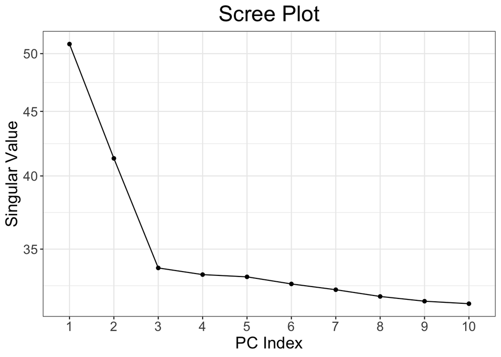

```r
plot(wecare.svd1) # default type="screeplot" see ?plot.big_SVD
```

```r
# Eigenvectors
dim(wecare.svd1$u)
```

```
## [1] 389  10
```

```r
head(wecare.svd1$u)
```

```
##              [,1]         [,2]         [,3]        [,4]        [,5]         [,6]         [,7]         [,8]        [,9]        [,10]
## [1,] -0.023588140 -0.009170970 -0.043911633  0.05038721 -0.03962468  0.115574862 -0.016638748 -0.044326984  0.02772802 -0.039823454
## [2,]  0.053647487 -0.004945949  0.000200578 -0.02813452  0.02537786  0.050254026 -0.043498448 -0.003923493 -0.01826473  0.080817550
## [3,] -0.178029742 -0.097744505 -0.057617746  0.05947232  0.04722262 -0.049173630  0.016326062  0.051965017  0.01891768  0.046932549
## [4,] -0.003696188 -0.023941199 -0.071777345  0.01931577 -0.02580011  0.013923649 -0.068475615 -0.031156133 -0.01890314  0.005518416
## [5,] -0.019015078  0.030829456 -0.017150775  0.07128749 -0.06016629  0.005635423 -0.001863546  0.055113683  0.02671079  0.027530045
## [6,]  0.040156933  0.030639918 -0.002866482 -0.08287078 -0.01343240 -0.015368423  0.035852823 -0.015985143 -0.04429235 -0.085409428
```

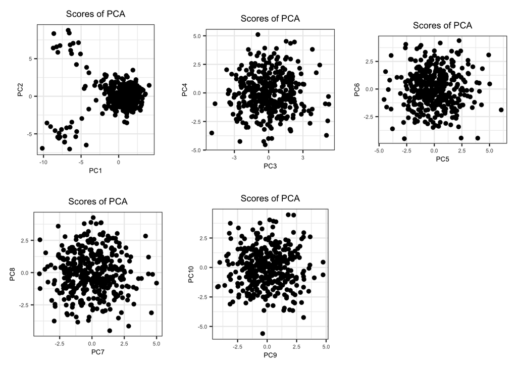

```r
# PCA summary (for PCs from 1 to 10)
plot(wecare.svd1,type = "scores",scores=1:10,coeff=0.4)
```

```r
# Loadings
dim(wecare.svd1$v)
```

```
## [1] 212  10
```

```r
head(wecare.svd1$v)
```

```
##              [,1]          [,2]        [,3]        [,4]         [,5]        [,6]        [,7]         [,8]         [,9]        [,10]
## [1,] -0.001718855  0.0001735872 0.009633964  0.01412659  0.056509790 -0.12875152  0.03350573  0.063637436  0.071681732  0.013931232
## [2,] -0.013251175 -0.0394991290 0.111893468  0.02199345 -0.036839828 -0.16027621 -0.04243581  0.020966840  0.015314186  0.042140962
## [3,]  0.026891004 -0.1327518404 0.015840081 -0.01777688 -0.008168355  0.08911555  0.02314708 -0.012951666 -0.042491847 -0.005666494
## [4,]  0.008088974 -0.0977503257 0.029239760  0.04541031 -0.079896744 -0.02631156  0.02418563 -0.018363648 -0.043754584 -0.019741386
## [5,]  0.015094874 -0.0524241289 0.083108338 -0.11972427  0.017569857  0.09742195  0.01153452 -0.066230880 -0.004979226 -0.035061837
## [6,] -0.028962031  0.0635121771 0.071799392  0.03292629 -0.037025385 -0.05818943 -0.11381348 -0.006832766 -0.043519705  0.027702214
```

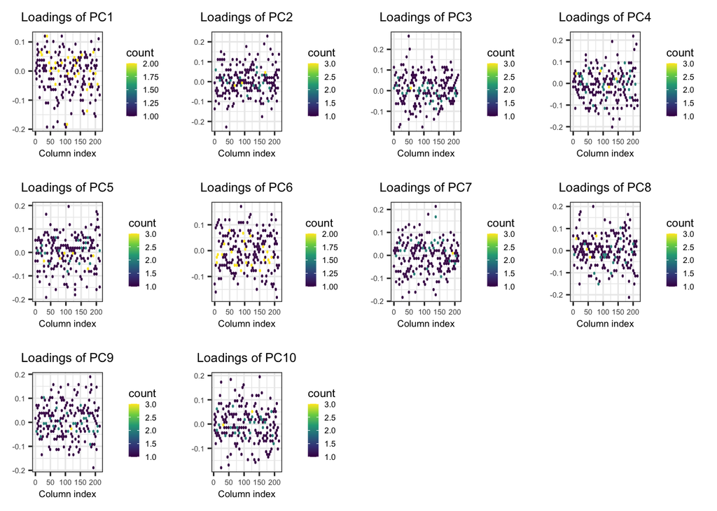

```r
# Loadings summary (for PCs from 1 to 10)
plot(wecare.svd1,type="loadings",loadings=1:10,coeff=0.4)
```

```r
# Calculate a measure of "outlieness"
U1 <- wecare.svd1$u
prob1 <- prob_dist(U1, ncores=NCORES) # bigutilsr::prob_dist
S1 <- prob1$dist.self / sqrt(prob1$dist.nn)
tukey_threshold1 <- tukey_mc_up(S1) # bigutilsr::tukey_mc_up

# Outliers
outliers1 <- S1 >= tukey_threshold1
sum(outliers1)
```

```
## [1] 0
```

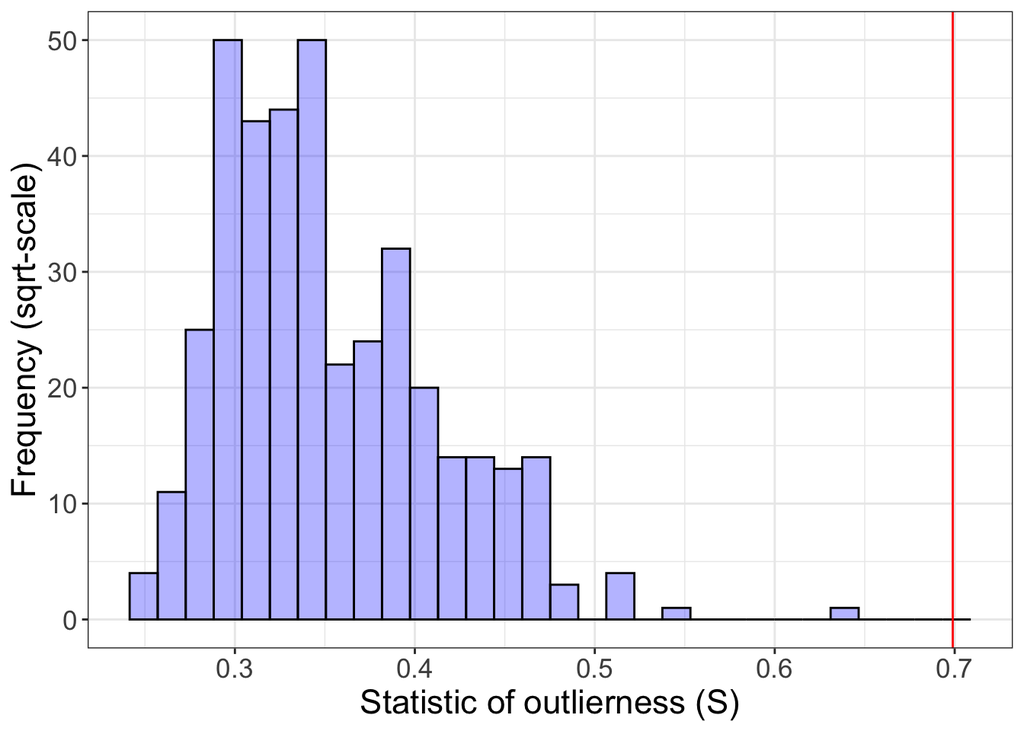

```r
# Histogram by "outlieness" score
ggplot() +
  geom_histogram(aes(S1), color = "black", fill = "blue", alpha = 0.3) +
  theme_bigstatsr() +
  geom_vline(xintercept=tukey_threshold1, colour="red") +
  labs(x = "Statistic of outlierness (S)", y = "Frequency (sqrt-scale)")
```

# 7 Update phenotypes table

```r
phenotypes_with_PCs.df <- wecare_phenotypes.df
eigenvectors.mx <- wecare.svd1$u

#phenotypes_with_PCs.df <- wecare_phenotypes.df[!wecare_phenotypes.df$outlier,]
#eigenvectors.mx <- wecare.svd2$u

dim(phenotypes_with_PCs.df)
```

```
## [1] 389  31
```

```r
dim(eigenvectors.mx)
```

```
## [1] 389  10
```

```r
colnames(eigenvectors.mx) <-
  c("pc1","pc2","pc3","pc4","pc5","pc6","pc7","pc8","pc9","pc10")

phenotypes_with_PCs.df <- cbind(phenotypes_with_PCs.df, eigenvectors.mx)
dim(phenotypes_with_PCs.df)
```

```
## [1] 389  41
```

```r
colnames(phenotypes_with_PCs.df)
```

```
##  [1] "family.ID"        "sample.ID"        "paternal.ID"      "maternal.ID"      "sex"              "affection"        "illumina_id"      "illumina_lane"    "Sample_num"       "cc"               "rstime"           "sub_dx_age"       "hormone_self_mra" "chemo_self_mra"   "treatment"        "Hist_l…
```

```r
# Clean-up
rm(wecare_phenotypes.df, eigenvectors.mx) # vars_not_in_LD1
#somehow close wecare.bed ?
```

# 8 Compare with PC-s calculated by PLINK

```r
plink_pcs_file <- file.path(data_folder,"s05_plink_pca","ampliseq_only_20PCs.eigenvec")
plink_pcs.df <- read.table(plink_pcs_file, header=T, sep="\t")
rownames(plink_pcs.df) <- plink_pcs.df$IID
plink_pcs.df <- plink_pcs.df[phenotypes_with_PCs.df$sample.ID,]
dim(plink_pcs.df)
```

```
## [1] 389  22
```

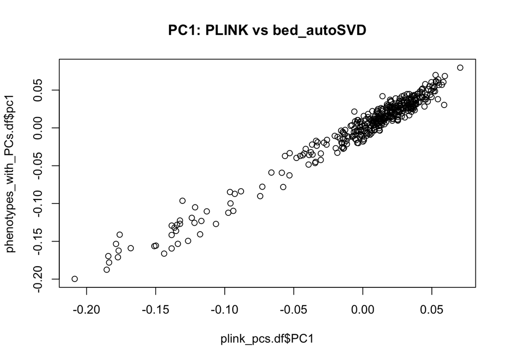

```r
# Check consistency with the previous eigenvectors from WES
plot(plink_pcs.df$PC1,
     phenotypes_with_PCs.df$pc1,
     main="PC1: PLINK vs bed_autoSVD")
```

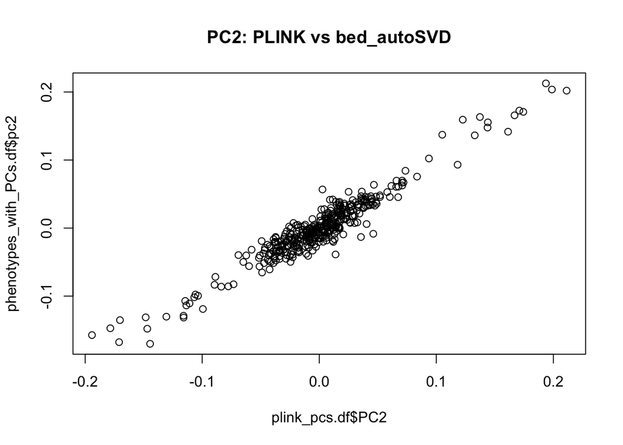

```r
plot(plink_pcs.df$PC2,
     phenotypes_with_PCs.df$pc2,
     main="PC2: PLINK vs bed_autoSVD")
```

```r
rm(plink_pcs_file, plink_pcs.df)
```

# 9 Calculate PC-outliers by 6xSD

```r
sd_threshold <- 6

# PC1 outliers
pc1 <- phenotypes_with_PCs.df$pc1
pc1_mean <- mean(pc1)
pc1_sd  <- sd(pc1)
lo_pc1 <- pc1 < pc1_mean - sd_threshold * pc1_sd
hi_pc1 <- pc1 > pc1_mean + sd_threshold * pc1_sd

cat("pc1 lo/hi:",sum(lo_pc1),"/",sum(hi_pc1),"\n")
```

```
## pc1 lo/hi: 0 / 0
```

```r
phenotypes_with_PCs.df$sample.ID[lo_pc1]
```

```
## character(0)
```

```r
phenotypes_with_PCs.df$sample.ID[hi_pc1]
```

```
## character(0)
```

```r
# PC2 outliers
pc2 <- phenotypes_with_PCs.df$pc2
pc2_mean <- mean(pc2)
pc2_sd  <- sd(pc2)
lo_pc2 <- pc2 < pc2_mean - sd_threshold * pc2_sd
hi_pc2 <- pc2 > pc2_mean + sd_threshold * pc2_sd

cat("pc2 lo/hi:",sum(lo_pc2),"/",sum(hi_pc2),"\n")
```

```
## pc2 lo/hi: 0 / 0
```

```r
phenotypes_with_PCs.df$sample.ID[lo_pc2]
```

```
## character(0)
```

```r
phenotypes_with_PCs.df$sample.ID[hi_pc2]
```

```
## character(0)
```

```r
rm(sd_threshold,
   pc1, pc1_mean, pc1_sd, lo_pc1, hi_pc1,
   pc2, pc2_mean, pc2_sd, lo_pc2, hi_pc2)
```

# 10 Detailed PCA plots

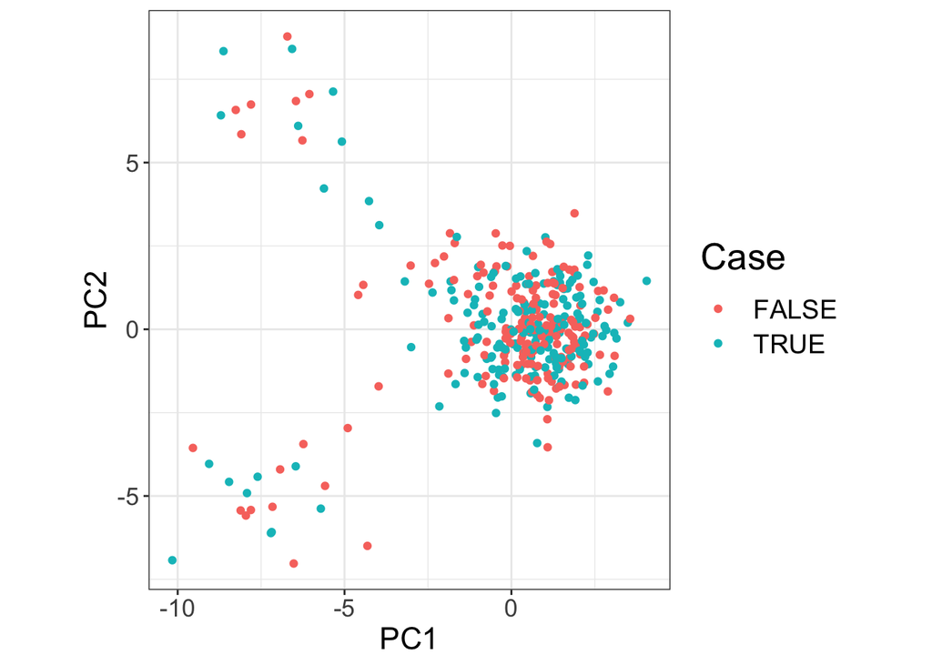

```r
selected_svd <- wecare.svd1
#selected_svd <- wecare.svd2

plot(selected_svd, type = "scores") +
     aes(color = phenotypes_with_PCs.df$affection == 2) +
     labs(title = NULL, color = "Case")
```

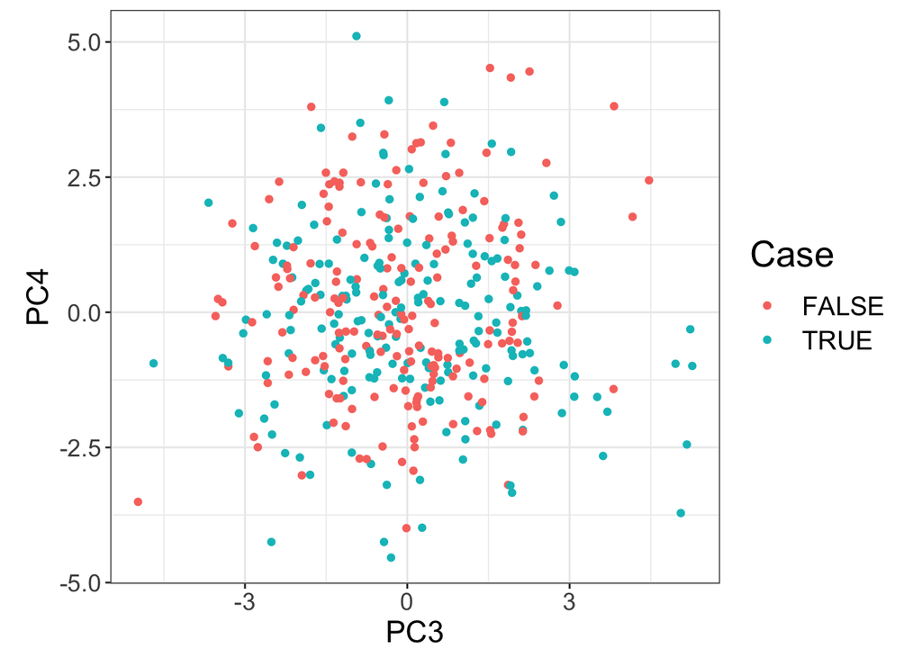

```r
# + geom_hline(pc2_mean - sd_threshold * pc2_sd,
#              linetype="dashed", color = "red")

plot(selected_svd, type = "scores", scores=3:4) +
     aes(color = phenotypes_with_PCs.df$affection == 2) +
     labs(title = NULL, color = "Case")
```

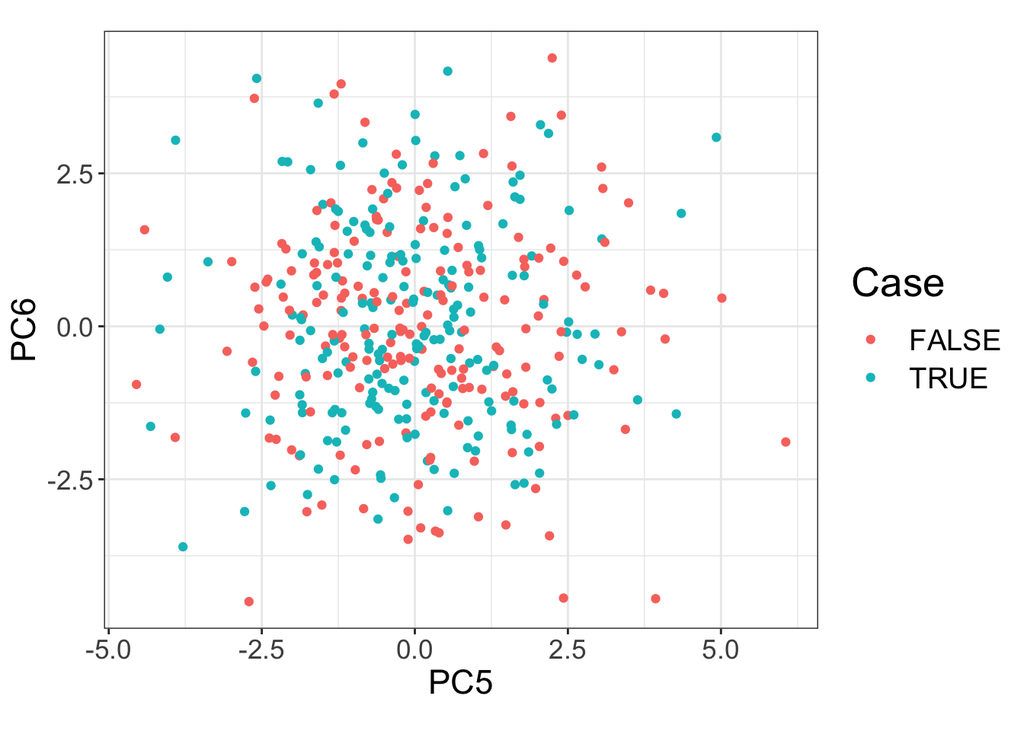

```r
plot(selected_svd, type = "scores", scores=5:6) +
     aes(color = phenotypes_with_PCs.df$affection == 2) +
     labs(title = NULL, color = "Case")
```

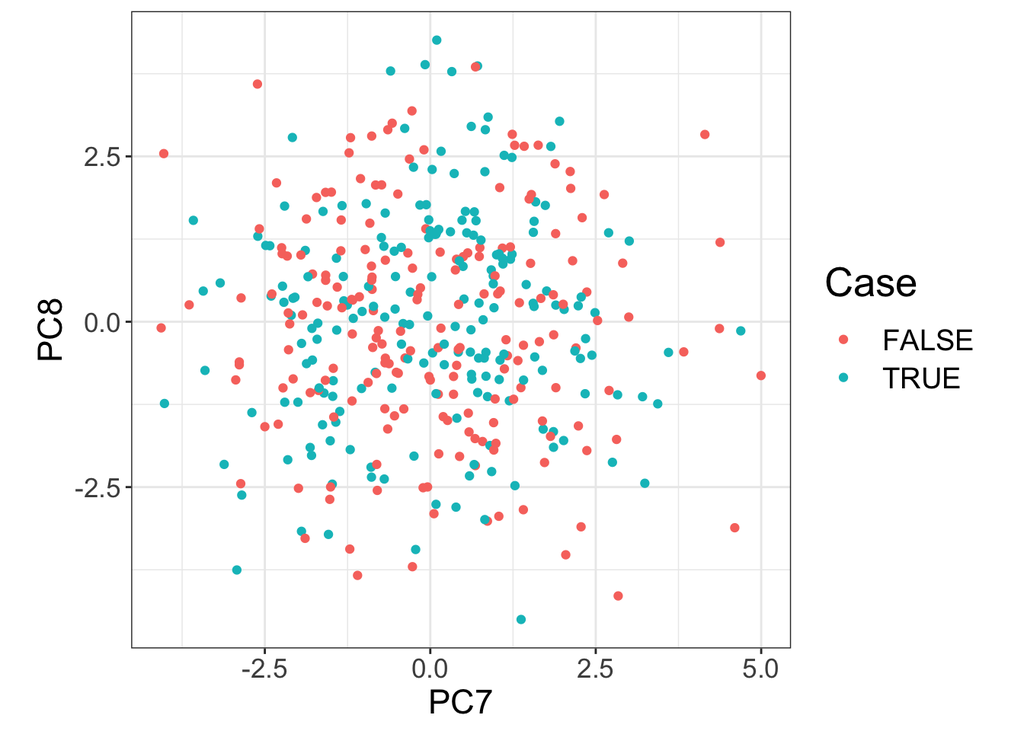

```r
plot(selected_svd, type = "scores", scores=7:8) +
     aes(color = phenotypes_with_PCs.df$affection == 2) +
     labs(title = NULL, color = "Case")
```

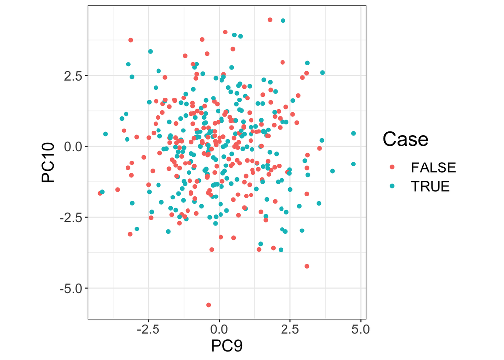

```r
plot(selected_svd, type = "scores", scores=9:10) +
     aes(color = phenotypes_with_PCs.df$affection == 2) +
     labs(title = NULL, color = "Case")
```

```r
rm(selected_svd)
```

# 11 Save results

```r
rm(NCORES,wecare.svd1,wecare.svd2,wecare.bed,wecare_variants.df)
```

```r
save.image(file.path(data_folder,"s06_calculate_PCs.RData"))
save(phenotypes_with_PCs.df,file=file.path(data_folder,"s06_phenotypes_with_PCs.RData"))
```

# 12 End section

```r
ls()
```

```
##  [1] "base_folder"            "data_folder"            "non_outliers1"          "outliers1"              "phenotypes_with_PCs.df" "prob1"                  "S1"                     "scripts_folder"         "tukey_threshold1"       "U1"                     "vars_not_in_LD1"
```

```r
Sys.time()
```

```
## [1] "2021-12-23 21:29:13 GMT"
```

```r
gc()
```

```
##           used  (Mb) gc trigger  (Mb) limit (Mb) max used  (Mb)
## Ncells 2178745 116.4    6902875 368.7         NA  6902875 368.7
## Vcells 3870733  29.6   12255594  93.6      16384  9223348  70.4
```